# Liquid Viscosity of Hydrocarbon Prediction Model

## Setup

Start by loading in the libraries that will be useful.

```r
library(tidyverse)
library(car)
library(lmtest)
```

## Model Setup

Now we need to create the data set that we’ll us to determine our regression coefficients. The goal is to reproduce the coefficients published by *Van Velzen et al*. We need to extract the published values for $N_E$ and $T_0$ from the appendices. Then, those data will be used to run a few different polynomial regression models on the data. The regression models will all use a simply monomial basis in a Vandermonde matrix.

```r
N_exp = c(0.79, 1.91, 3.13, 4.07, 4.91, 5.91, 7.04, 7.97, 9.05, 9.99,
       11.04, 11.99, 12.99, 13.98, 15.02, 16.00, 17.01, 18.01, 19.00, 19.98)

T0 = c(57.60, 95.57, 133.41, 160.20, 182.48, 207.09, 232.53, 251.71, 272.12, 288.37,
       305.01, 318.78, 332.10, 344.21, 355.92, 366.11, 375.90, 385.00, 393.54, 401.67)

B_exp = c(114.14, 156.60, 222.67, 265.84, 313.66, 362.79, 436.73, 473.70, 525.56, 558.61,
      605.50, 631.63, 664.10, 689.85, 718.51, 738.30, 757.88, 777.40, 793.62, 811.29)

df_raw = data.frame(N_exp, T0, B_exp)

N = N_exp
N2 = N^2
N3 = N * N2
N4 = N * N3
```

Perform regressions to determine the coefficients for $T_0$.

```r
fit_quadratic_T0 = lm(T0 ~ N_exp + I(N_exp^2), data = df_raw)
summary(fit_quadratic_T0)
```

```
Call:
lm(formula = T0 ~ N_exp + I(N_exp^2), data = df_raw)

Residuals:
    Min      1Q  Median      3Q     Max
-6.4782 -2.4699  0.0361  2.6625  6.1493

Coefficients:
            Estimate Std. Error t value Pr(>|t|)
(Intercept) 39.29147    2.52190   15.58 1.69e-11 ***
N_exp       31.93327    0.55398   57.64  < 2e-16 ***
I(N_exp^2)  -0.70590    0.02571  -27.46 1.60e-15 ***
---
Signif. codes:  0 ‘***’ 0.001 ‘**’ 0.01 ‘*’ 0.05 ‘.’ 0.1 ‘ ’ 1

Residual standard error: 3.449 on 17 degrees of freedom
Multiple R-squared:  0.999, Adjusted R-squared:  0.9989
F-statistic:  8666 on 2 and 17 DF,  p-value: < 2.2e-16
```

```r
fit_cubic_T0 = lm(T0 ~ N_exp + I(N_exp^2) + I(N_exp^3), data = df_raw)
summary(fit_cubic_T0)
```

```
Call:
lm(formula = T0 ~ N_exp + I(N_exp^2) + I(N_exp^3), data = df_raw)

Residuals:
       Min         1Q     Median         3Q        Max
-0.0038136 -0.0024986 -0.0008026  0.0036044  0.0044992

Coefficients:
              Estimate Std. Error t value Pr(>|t|)
(Intercept)  2.886e+01  3.429e-03    8417   <2e-16 ***
N_exp        3.744e+01  1.388e-03   26982   <2e-16 ***
I(N_exp^2)  -1.355e+00  1.530e-04   -8853   <2e-16 ***
I(N_exp^3)   2.076e-02  4.832e-06    4296   <2e-16 ***
---
Signif. codes:  0 ‘***’ 0.001 ‘**’ 0.01 ‘*’ 0.05 ‘.’ 0.1 ‘ ’ 1

Residual standard error: 0.00331 on 16 degrees of freedom
Multiple R-squared:      1, Adjusted R-squared:      1
F-statistic: 6.278e+09 on 3 and 16 DF,  p-value: < 2.2e-16
```

```r
fit_quartic_T0 = lm(T0 ~ N_exp + I(N_exp^2) + I(N_exp^3) + I(N_exp^4), data = df_raw)
summary(fit_quartic_T0)
```

```
Call:
lm(formula = T0 ~ N_exp + I(N_exp^2) + I(N_exp^3) + I(N_exp^4),
    data = df_raw)

Residuals:
       Min         1Q     Median         3Q        Max
-0.0039346 -0.0024526 -0.0004255  0.0035883  0.0044618

Coefficients:
              Estimate Std. Error   t value Pr(>|t|)
(Intercept)  2.886e+01  4.613e-03  6255.547   <2e-16 ***
N_exp        3.744e+01  2.939e-03 12738.915   <2e-16 ***
I(N_exp^2)  -1.355e+00  5.626e-04 -2409.035   <2e-16 ***
I(N_exp^3)   2.080e-02  4.044e-05   514.233   <2e-16 ***
I(N_exp^4)  -8.792e-07  9.676e-07    -0.909    0.378
---
Signif. codes:  0 ‘***’ 0.001 ‘**’ 0.01 ‘*’ 0.05 ‘.’ 0.1 ‘ ’ 1

Residual standard error: 0.003329 on 15 degrees of freedom
Multiple R-squared:      1, Adjusted R-squared:      1
F-statistic: 4.657e+09 on 4 and 15 DF,  p-value: < 2.2e-16
```

### Notes

Testing different polynomial regressions, the cubic fit is the best. The $R^2$ values for all flavours were very high. The quartic fit is redundant, the extra term does not contribute anything to the fit. Give that the $R^2$ value for the cubic model is 1, this is no surprise at all.

The coefficients for the cubic model are:

$\beta_0 = 28.859$, $\beta_1 = 37.439$, $\beta_2 = -1.3547$, $\beta_3 = 0.02076$

These coefficients reproduce those published by *Van Velzen et al.* in Eq. 7 (pg 7).

```r
coef(fit_cubic_T0)
```

```
(Intercept)       N_exp  I(N_exp^2)  I(N_exp^3)
28.85931432 37.43915692 -1.35472027  0.02076003
```

Perform regressions to determine the coefficients for $B$.

```r
fit_quadratic_B = lm(B_exp ~ N_exp + I(N_exp^2), data = df_raw)
summary(fit_quadratic_B)
```

```
Call:
lm(formula = B_exp ~ N_exp + I(N_exp^2), data = df_raw)

Residuals:
    Min      1Q  Median      3Q     Max
-15.888  -3.466   1.086   4.077  23.803

Coefficients:
            Estimate Std. Error t value Pr(>|t|)
(Intercept) 40.02779    6.90876   5.794 2.16e-05 ***
N_exp       64.71716    1.51764  42.643  < 2e-16 ***
I(N_exp^2)  -1.30992    0.07042 -18.601 9.75e-13 ***
---
Signif. codes:  0 ‘***’ 0.001 ‘**’ 0.01 ‘*’ 0.05 ‘.’ 0.1 ‘ ’ 1

Residual standard error: 9.449 on 17 degrees of freedom
Multiple R-squared:  0.9984,    Adjusted R-squared:  0.9982
F-statistic:  5392 on 2 and 17 DF,  p-value: < 2.2e-16
```

```r
fit_cubic_B = lm(B_exp ~ N_exp + I(N_exp^2) + I(N_exp^3), data = df_raw)
summary(fit_cubic_B)
```

```
Call:
lm(formula = B_exp ~ N_exp + I(N_exp^2) + I(N_exp^3), data = df_raw)

Residuals:
    Min      1Q  Median      3Q     Max
-12.243  -5.837  -1.579   6.021  14.823

Coefficients:
            Estimate Std. Error t value Pr(>|t|)
(Intercept) 54.49102    8.70051   6.263 1.13e-05 ***
N_exp       57.08376    3.52107  16.212 2.37e-11 ***
I(N_exp^2)  -0.41040    0.38833  -1.057   0.3063
I(N_exp^3)  -0.02878    0.01226  -2.347   0.0321 *
---
Signif. codes:  0 ‘***’ 0.001 ‘**’ 0.01 ‘*’ 0.05 ‘.’ 0.1 ‘ ’ 1

Residual standard error: 8.401 on 16 degrees of freedom
Multiple R-squared:  0.9988,    Adjusted R-squared:  0.9986
F-statistic:  4550 on 3 and 16 DF,  p-value: < 2.2e-16
```

```r
fit_quartic_B = lm(B_exp ~ N_exp + I(N_exp^2) + I(N_exp^3) + I(N_exp^4), data = df_raw)
summary(fit_quartic_B)
```

```
Call:
lm(formula = B_exp ~ N_exp + I(N_exp^2) + I(N_exp^3) + I(N_exp^4),
    data = df_raw)

Residuals:
    Min      1Q  Median      3Q     Max
-4.9697 -3.2276  0.6626  2.1856 10.4040

Coefficients:
             Estimate Std. Error t value Pr(>|t|)
(Intercept) 81.643992   5.764914  14.162 4.36e-10 ***
N_exp       34.166456   3.673119   9.302 1.28e-07 ***
I(N_exp^2)   4.383204   0.703037   6.235 1.60e-05 ***
I(N_exp^3)  -0.384460   0.050541  -7.607 1.59e-06 ***
I(N_exp^4)   0.008572   0.001209   7.089 3.69e-06 ***
---
Signif. codes:  0 ‘***’ 0.001 ‘**’ 0.01 ‘*’ 0.05 ‘.’ 0.1 ‘ ’ 1

Residual standard error: 4.16 on 15 degrees of freedom
Multiple R-squared:  0.9997,    Adjusted R-squared:  0.9997
F-statistic: 1.393e+04 on 4 and 15 DF,  p-value: < 2.2e-16
```

```r
coef(fit_cubic_B)
```

```
(Intercept)       N_exp  I(N_exp^2)  I(N_exp^3)
54.49101622 57.08376353 -0.41040071 -0.02878187
```

The B regression coefficients do not match those published by *Van Velzen et al.* but they do produce a better fit and more accurate approximations of the viscosity of ethane over the given temperature range (the boiling point of ethane is $-88.5^\circ C$).

## Sanity Checking the Model

First, we need to define some helper functions that will aid in calculations.

```r
T0_calc <- function(coeffs, N) {
  T0_approx = coeffs[1] + coeffs[2]*N + coeffs[3]*N^2 + coeffs[4]*N^3
  return (T0_approx)
}

B_calc <- function(coeffs, N) {
  B_approx = coeffs[1] + coeffs[2]*N + coeffs[3]*N^2  + coeffs[4]*N^3
  return (B_approx)
}

viscosity_calc <- function(T0, B, Temperature) {
  log_visc = B*(1/Temperature - 1/T0)
  # The log in the de Guzman eqn is base 10.
  return(10^(log_visc))
}
```

#### Viscosity Function: De Guzman - Andrade

Once the regression coefficients have been determined, we can use them to calculate values of viscosity v. temperature. The equation that is used for this is Eq 6 (page 7), the De Guzman-Andrade equation.

$log(\eta_L) = B\biggl[\frac{1}{T} - \frac{1}{T_0} \biggr]$

Note that the log in the above equation is base 10, not base e and the temperatures must be in the Kelvin scale NOT Celsius.

[output not shown]

[output not shown]

[output not shown]

[output not shown]

[output not shown]

[output not shown]

[output not shown]

[output not shown]

[output not shown]

[output not shown]

[output not shown]

[output not shown]

[output not shown]

[output not shown]

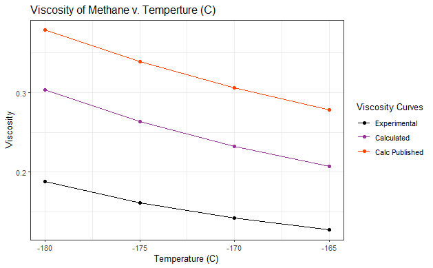

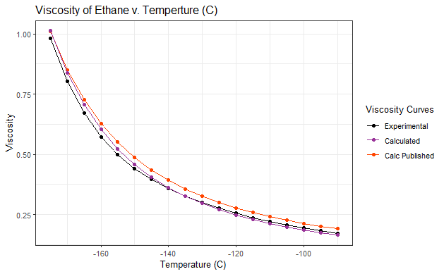

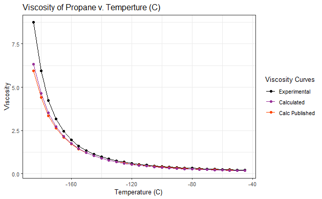

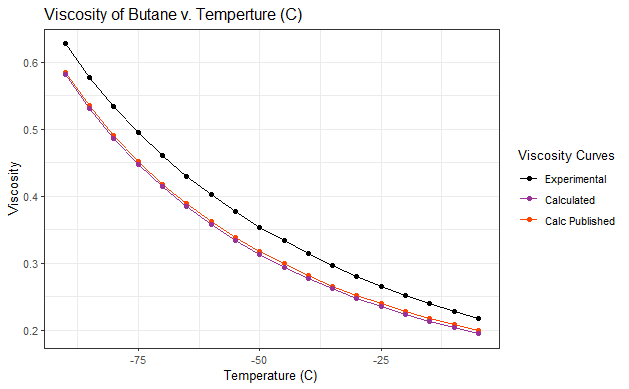

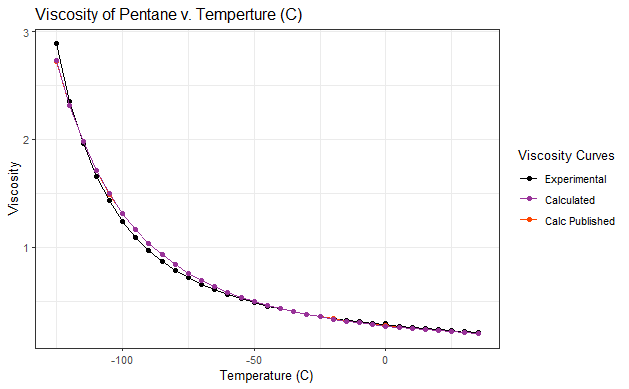

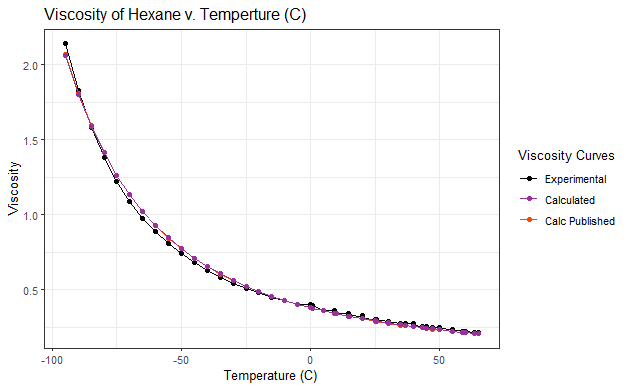

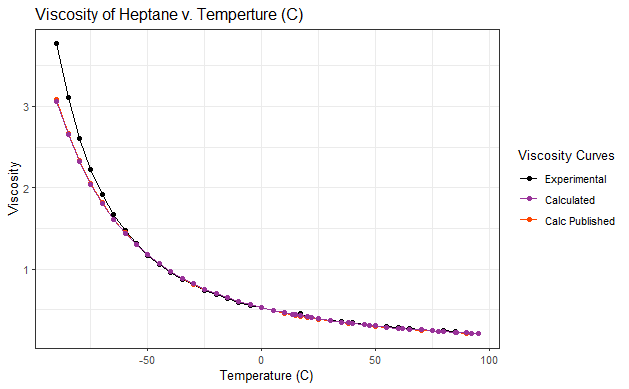

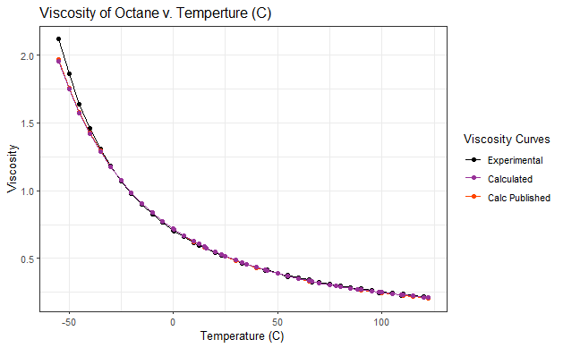

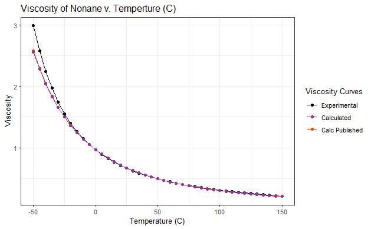

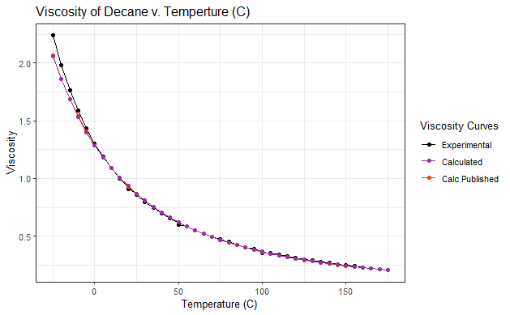

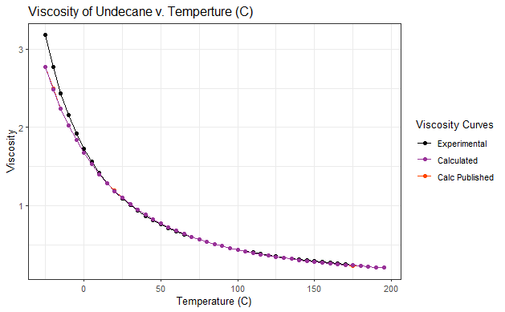

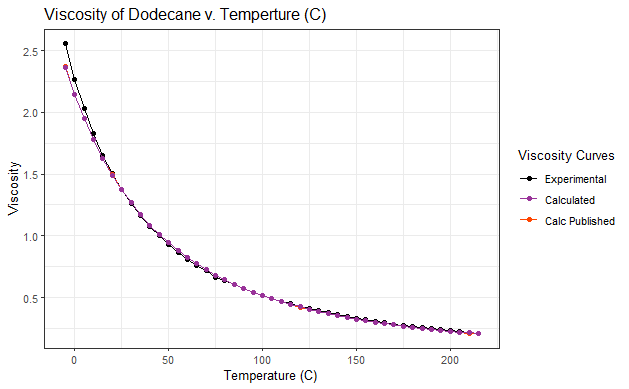

[3 more figures not shown]

```r
T_coeffs = coef(fit_cubic_T0)
B_coeffs = coef(fit_cubic_B)

alkane_names = c("Methane","Ethane", "Propane", "Butane", "Pentane", "Hexane", "Heptane", "Octane", "Nonane", "Decane",
                 "Undecane", "Dodecane", "Tridecane", "Tetradecane", "Pentadecane")

for (i in 1:15) {
  filename = paste0("data/",i,"-temp-viscosity.csv")
  alkane_tbl = read_csv(filename, col_names = TRUE)

  # generate the constants for the current alkane
  T0_alkane = T0_calc(T_coeffs, i)
  B_alkane = B_calc(B_coeffs,i)

  # Add a new column with temps in Kelvin for use in calculations
  alkane_tbl = alkane_tbl %>%
    mutate(TempK = alkane_tbl$Temp + KELVIN)

  # Compute viscosity
  alkane_tbl = alkane_tbl %>%
    mutate(CalcTest = viscosity_calc(T0_alkane, B_alkane, alkane_tbl$TempK))

  plot_title = paste0("Viscosity of ", alkane_names[i], " v. Temperture (C)")

  print(alkane_tbl %>%
    ggplot(aes(x=Temp)) +
    geom_point(aes(y=Exp, color="Experimental")) +
    geom_line(aes(y=Exp, color="Experimental")) +
    geom_point(aes(y=Calc, color="Calc Published")) +
    geom_line(aes(y=Calc, color="Calc Published")) +
    geom_point(aes(y=CalcTest, color="Calculated")) +
    geom_line(aes(y=CalcTest, color="Calculated")) +
    theme_bw() +
    theme(legend.position="right") +
    labs(x="Temperature (C)", y="Viscosity", title=plot_title) +
    scale_color_manual(name="Viscosity Curves", values = c("Experimental"="#000000","Calculated"="#993399", "Calc Published"="#ff4500")))

}
```

```r
filename = paste0("data/",2,"-temp-viscosity.csv")
ethane_tbl = read_csv(filename, col_names = TRUE)
```

```
* `` -> ...1
```

```r
# Add a new column with temps in Kelvin for use in calculations
ethane_tbl = ethane_tbl %>%
  mutate(TempK = ethane_tbl$Temp + KELVIN)


fit = lm(log10(ethane_tbl$Exp) ~ ethane_tbl$TempK)
summary(fit)
```

```
Call:
lm(formula = log10(ethane_tbl$Exp) ~ ethane_tbl$TempK)

Residuals:
     Min       1Q   Median       3Q      Max
-0.04465 -0.03539 -0.01142  0.02389  0.09902

Coefficients:
                   Estimate Std. Error t value Pr(>|t|)
(Intercept)       0.7191395  0.0559297   12.86 7.52e-10 ***
ethane_tbl$TempK -0.0084162  0.0003911  -21.52 3.08e-13 ***
---
Signif. codes:  0 ‘***’ 0.001 ‘**’ 0.01 ‘*’ 0.05 ‘.’ 0.1 ‘ ’ 1

Residual standard error: 0.04304 on 16 degrees of freedom
Multiple R-squared:  0.9666,    Adjusted R-squared:  0.9645
F-statistic: 463.2 on 1 and 16 DF,  p-value: 3.08e-13
```

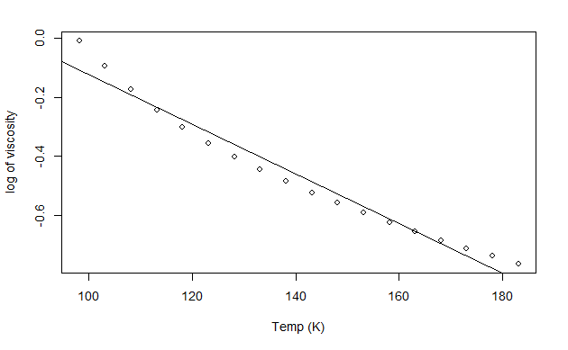

```r
plot(log10(ethane_tbl$Exp) ~ ethane_tbl$TempK, ylab='log of viscosity', xlab='Temp (K)')
abline(fit)
```

### TODO:

1.) inverse of temp diff for methane 2.) higher order fits (higher order for bigger molecules) 3.) plot fits for N > 10 alkanes